# STA 141A Final Project

Junqing He, junehe@ucdavis.edu

Ziyi Zeng, jerzeng@ucdavis.edu

Yucheng Zhao, yuczhao@ucdavis.edu

Tracy Zhu, tcizhu@ucdavis.edu

Haitong Zhu, htjzhu@ucdavis.edu

11/27/2022

# Contribution

Ziyi Zeng and Haitong Zhu are mainly responsible for coding and the final integration of the project report. Ziyi mainly writes code to preliminarily process the data and visually present the relationship between the data variables. Haitong mainly codes for the model establishment and analysis. Junqing He is mainly responsible for writing the introduction of the project, the description of data variables, and the analysis of data visualization. Tracy Zhu and Yucheng Zhao are mainly responsible for interpreting the results and writing the methodology, model analysis, conclusions, and answers to our research questions in our report. All team members held 3 discussion meetings together and contributed to the project efficiently and successfully.

# Introduction and Background

The heart is the muscle at the center of the cardiovascular system and has the primary function of circulating blood and oxygen around the human body. Because of this re- sponsibility, small abnormalities may have significant harmful effects to the body. The association of disorders of the heart and blood vessels are defined as cardiovascular dis- ease (CVD). This includes coronary heart disease, cerebrovascular disease, peripheral arterial disease, rheumatic heart disease, continental heart disease, deep vein thrombosis and pulmonary embolism [1].

The American Heart Association (AHA) reports that about 25% of the population in the United States currently have some form of cardiovascular disease (CVD) and about 47% of all Americans have at least 1 of 3 key risk factors for heart disease – high blood pressure, high cholesterol, and smoking. One person dies every 36 seconds because of CVD and 1 in every 4 deaths is related to heart disease. Furthermore, 20% of heart attacks are silent and patients are not aware of the damage done to their bodies. Recently, the sudden onset of the COVID-19 pandemic has raised the risk for CVD patients. The most common clinical manifestations of COVID-19 are respiratory related, which can arise as a mild flu-like sickness to potentially fatal acute respiratory distress syndrome or fulminant pneumonia [2]. Acute cardiac injury, heart failure, and arrhythmia are among some of the reported cardiovascular complications in patients, along with COVID-19. This indicates people who already have pre-existing CVD are more vulnerable to COVID-19 variants than those who do not.

Many types of CVD have extensive pre-symptomatic stages during which low-cost treat- ment can help improve results. Our project aims to use statistics methods to analyze the known factors of CVD patients. The models list out the factors that correlate to the existence of CVD. Then, a patient suspecting of CVD could ask for the professional analysis such as echocardiographic screening [4], test for C-reactive protein (CPR) [3], or they can pay extra attention to their diet and daily consumption[5] to prevent the CVD.

The prevalence of CVD makes it the leading cause of death for both men and women in the United States. However, the World Health Organization estimates that over 75% of premature CVD is preventable. Therefore, detecting and preventing the factors of heart disease have a great impact on the health of the United States population.

# Methodology overview

To begin with, we observed, cleaned, and organized the raw data. We attempt to measure the performance of a model for predicting heart disease. To identify and remove errors and duplicate data to create usable datasets, we first use `na.omit` to find the data with missing values and clean them out. Then we are able to remove the rows containing missing values to prevent data corruption or failure to record data.

After processing the original data, we plan to use the supervised learning technique in this project. We split data into the training set and the test set to avoid overfitting. We chose 80% of the rows in the data for the training set and the rest 20% for the testing set randomly. [1]

Then we create a Generalized linear model (GLM) model with the data in the training set, the dependent variable is heart disease, while the 17 independent variables are BMI, Smoking, Alcohol Drinking, Stroke, Physical Health, Mental Health, Diff Walking, Sex, Age Catagory, Race, Diabetic, Physical Activity, Gen Health, Sleep Time, Asthma, Kidney Disease, and Skin Cancer. It is clear that we should use binomial regression to fit the model because we want to find the relationship between the probability of success of the binomially distributed variable Heart Disease and 17 independent variables.

After creating the preliminary model, we intend to verify whether the model’s predictions are valid or not. So we made a confusion matrix and create a ROC curve (receiver operating characteristic curve) based on that which uses the results from the training set to predict 20% of the data to test the accuracy rate.

We observed that the number of individuals who reported that they had heart disease (yes) was significantly less than the number who did not have heart disease (no). Since we need to balance data to make the model more accurate, we look for the total number of “yes” data in heart disease and then randomly select the same number of “no” data. Then we combine these two equal numbers of data into `data_new`.

Lastly, we did the same visualization and GLM analysis as the first model again with the new data.

# Dataset Description and Exploratory Data Analysis

The chosen dataset is the 2020 annual CDC survey of the health status of 400k adults in the United States. The data is a part of the Behavioral Risk Factor Surveillance System (BRFSS), which conducts annual telephone surveys to gather data on the health status of US residents. The dataset contains 319795 rows with 18 attributes, ranging from whether the respondents have ever reported having heart disease, to their body mass index, set, race, and age, physical, and mental health status, to whether they smoke or drink alcohol, to whether they have had a stroke, difficulty walking or climbing stairs. Some attributes have boolean values of yes or no, such as smoking, drinking, and stroke, some have others have categorical values like age, race, and general health, and some have floating point values, such as physical and mental health.

The dependent variable is under the column “HeartDisease”, which represents whether the respondents have ever reported having coronary heart disease (CHD) or myocardial infarction (MI) and the independent variables will be the remaining variables of the dataset after being further reduced. The majority of the samples in the dataset report not having heart disease. A little less than 300,000 people report never having heart disease, while 25,000 people report having heart disease out of the nearly 320,000 samples collected.

We chose this dataset because it has data applicable to the residents of the United States, which allows additional users within the United States to get more accurate results. The goal of this project is to use generalized linear model to predict whether an individual is at risk of heart disease or not. With the result information, people will be able to seek medical advice before a heart attack or something else harmful happens and lead a healthier life. The original dataset from the CDC had nearly 300 variables that were reduced to 18 variables by the creator of the dataset. And our group plans on using all 18 variables to build the model.

Firstly, we checked the numerical independent variables and found there exist some large outliers from the data because the maximum number is way much larger than the 3rd quartile in the summary table. Also, some values are not reasonable in real life. For example, a person’s BMI could not be 75, and nobody would sleep around 24 hours per day. We drew the boxplots to see the distribution and outliers of the numerical data. From the boxplots, we decide to remove the rows that contain the top one percent and the bottom one percent of the `BMI` and `SleepTime` value in the dataset.

```
##       BMI        PhysicalHealth    MentalHealth      SleepTime
##  Min.   :12.02   Min.   : 0.000   Min.   : 0.000   Min.   : 1.000
##  1st Qu.:24.03   1st Qu.: 0.000   1st Qu.: 0.000   1st Qu.: 6.000
##  Median :27.34   Median : 0.000   Median : 0.000   Median : 7.000
##  Mean   :28.33   Mean   : 3.372   Mean   : 3.898   Mean   : 7.097
##  3rd Qu.:31.42   3rd Qu.: 2.000   3rd Qu.: 3.000   3rd Qu.: 8.000
##  Max.   :94.85   Max.   :30.000   Max.   :30.000   Max.   :24.000
```

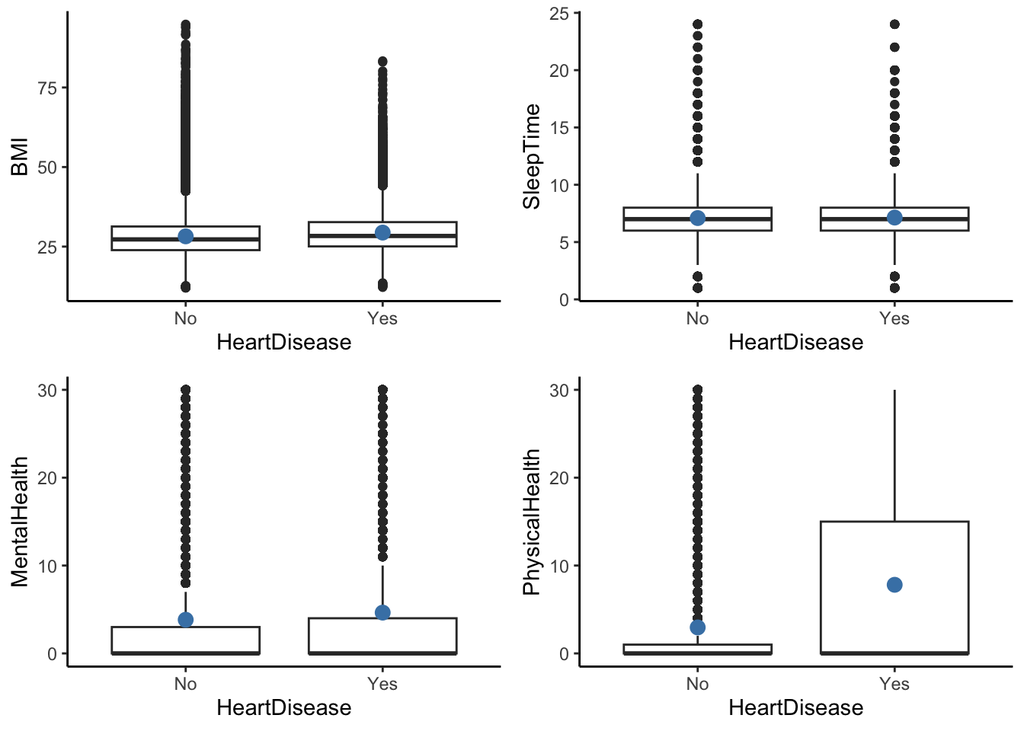

Then, we look at the relationship between categorical predictors proportions and whether the person has heart disease to further understand the data.

1. The person with higher BMI is more likely to have heart disease.
2. The proportion of males with heart disease is larger than the proportion of females with heart disease.
3. It is more likely for people who smoke to get heart disease.
4. The probability of people of different races to get heart disease varies. And Asian and Hispanic people seem to have lower rate with heart disease.
5. People with fair or poor general health have higher possibility to have heart disease.
6. Adults who reported doing physical activity or exercise during the past 30 days other than their regular job has lower chance to have heart disease.
7. Surprisingly, heavy drinkers (adult men having more than 14 drinks per week and adult women having more than 7 drinks per week) have lower probability to have heart disease. But this might because of the people with poor health condition are not allowed to drink that often.
8. If a person had a stroke before, he/she has higher chance to have heart disease.
9. The more often people with physical illness and injury during the past 30 days, the more possible for him/her to have heart disease.
10. There does not show any clear pattern between mental health and whether a person have heart disease.
11. The heart disease becomes more prevalent as an individual increases in age.
12. If a person has serious difficulty walking or climbing stairs, he/she has higher probability to have heart disease.
13. People with diabetes (not during pregnancy) or borderline diabetes are more possible to have heart disease.
14. People with asthma are more possible to have heart disease.
15. People with kidney disease have much higher chance to have heart disease.
16. Sleeping around six to eight hours per day has the lowest probability to get heart disease. Sleeping too much or too little might increase the risk of heart disease.
17. If a person had skin cancer before, he/she has higher chance to have heart disease.

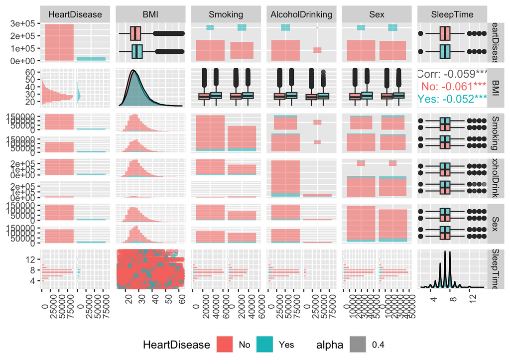

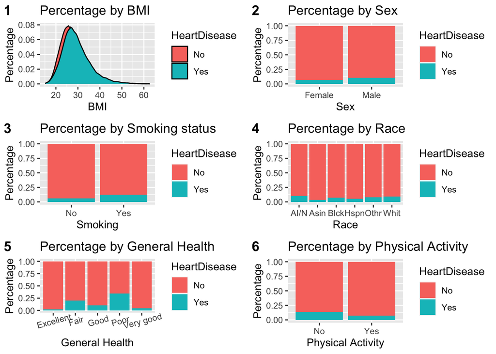

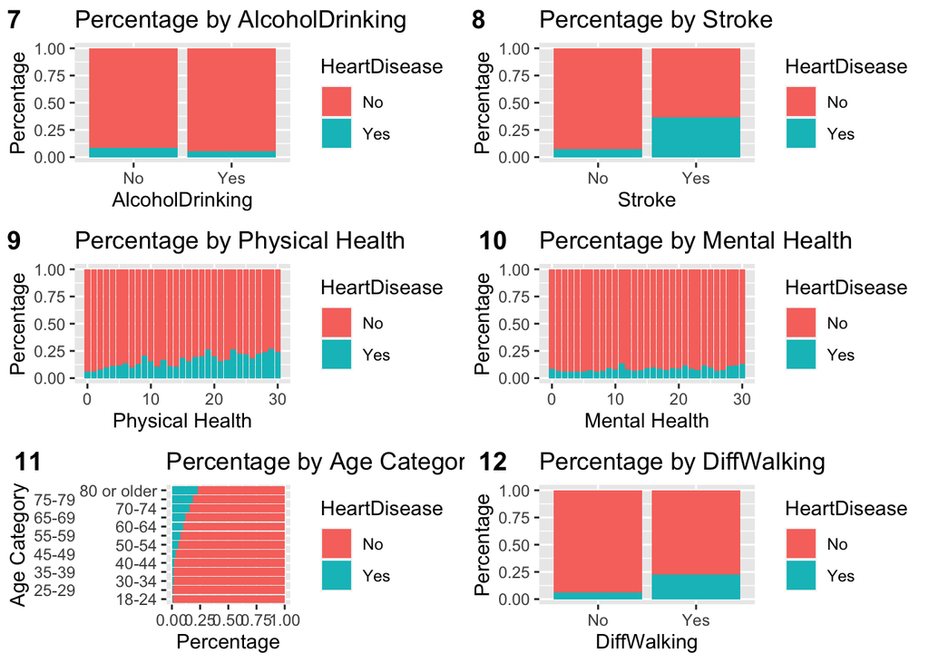

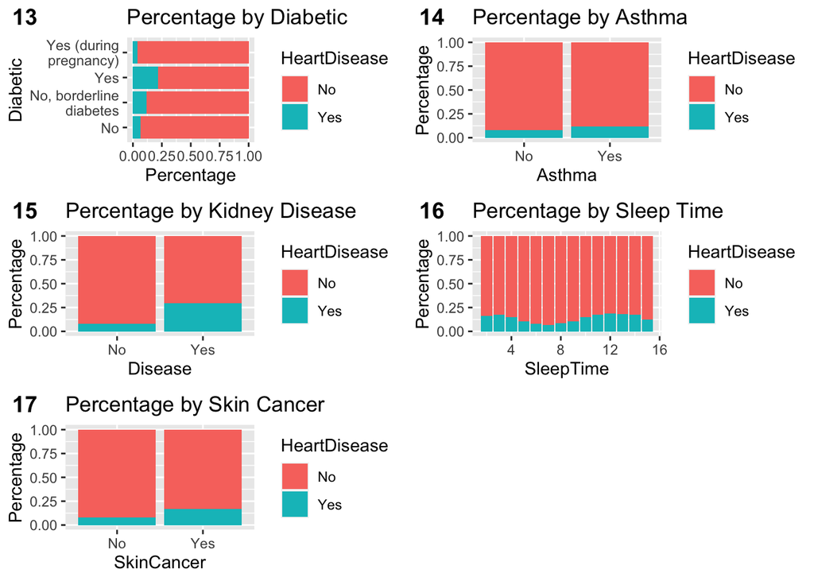

#### Training and Testing

Since our dependent variable HeartDisease is binary and has only yes and no categories, we converted the values under HeartDisease to 0 and 1 with the ifelse function that has 0 representing the respondent with no reported heart disease and one representing the respondent with reported heart disease. To ensure the precision and accuracy of our model, we split heart_data into a training set and a testing set, named heart_train and heart_test respectively. Here we implemented a 80 - 20 ratio. The training set consists of randomly selected 80% of the total rows (without replacement), whereas the testing set being the 20% rest. Later we will develop a Generalized Linear Model base on the training set and check the model with the testing set.

#### GLM model

```
##
## Call:
## glm(formula = HeartDisease ~ ., family = "binomial", data = heart_train)
##
## Deviance Residuals:
##     Min       1Q   Median       3Q      Max
## -2.1337  -0.4102  -0.2438  -0.1301   3.6042
##
## Coefficients:
##                                   Estimate Std. Error z value Pr(>|z|)
## (Intercept)                     -6.2586782  0.1287039 -48.628  < 2e-16 ***
## BMI                              0.0093400  0.0013273   7.037 1.97e-12 ***
## SmokingYes                       0.3502064  0.0161481  21.687  < 2e-16 ***
## AlcoholDrinkingYes              -0.2475536  0.0378644  -6.538 6.24e-11 ***
## StrokeYes                        1.0427726  0.0255659  40.788  < 2e-16 ***
## PhysicalHealth                   0.0030600  0.0009726   3.146  0.00165 **
## MentalHealth                     0.0040570  0.0009987   4.062 4.86e-05 ***
## DiffWalkingYes                   0.2195929  0.0203817  10.774  < 2e-16 ***
## SexMale                          0.7235178  0.0163846  44.159  < 2e-16 ***
## AgeCategory25-29                 0.1562770  0.1364672   1.145  0.25214
## AgeCategory30-34                 0.4769533  0.1233308   3.867  0.00011 ***
## AgeCategory35-39                 0.4950251  0.1195516   4.141 3.46e-05 ***
## AgeCategory40-44                 0.9969561  0.1109714   8.984  < 2e-16 ***
## AgeCategory45-49                 1.2859392  0.1071669  11.999  < 2e-16 ***
## AgeCategory50-54                 1.7295618  0.1031807  16.762  < 2e-16 ***
## AgeCategory55-59                 1.9472188  0.1016371  19.159  < 2e-16 ***
## AgeCategory60-64                 2.1862578  0.1007421  21.702  < 2e-16 ***
## AgeCategory65-69                 2.4364800  0.1004046  24.267  < 2e-16 ***
## AgeCategory70-74                 2.7296061  0.1003260  27.207  < 2e-16 ***
## AgeCategory75-79                 2.9199224  0.1009528  28.924  < 2e-16 ***
## AgeCategory80 or older           3.1872224  0.1006503  31.666  < 2e-16 ***
## RaceAsian                       -0.5288123  0.0942047  -5.613 1.98e-08 ***
## RaceBlack                       -0.3724892  0.0646351  -5.763 8.27e-09 ***
## RaceHispanic                    -0.2634873  0.0656744  -4.012 6.02e-05 ***
## RaceOther                       -0.0475989  0.0714102  -0.667  0.50506
## RaceWhite                       -0.1001993  0.0575665  -1.741  0.08176 .
## DiabeticNo, borderline diabetes  0.1284200  0.0472027   2.721  0.00652 **
## DiabeticYes                      0.4783814  0.0187861  25.465  < 2e-16 ***
## DiabeticYes (during pregnancy)   0.1927652  0.1150962   1.675  0.09397 .
## PhysicalActivityYes              0.0101599  0.0180276   0.564  0.57304
## GenHealthFair                    1.5056013  0.0367938  40.920  < 2e-16 ***
## GenHealthGood                    1.0449874  0.0330613  31.608  < 2e-16 ***
## GenHealthPoor                    1.9035193  0.0459788  41.400  < 2e-16 ***
## GenHealthVery good               0.4580481  0.0339671  13.485  < 2e-16 ***
## SleepTime                       -0.0256094  0.0052462  -4.882 1.05e-06 ***
## AsthmaYes                        0.2781430  0.0215594  12.901  < 2e-16 ***
## KidneyDiseaseYes                 0.5720177  0.0274177  20.863  < 2e-16 ***
## SkinCancerYes                    0.1099311  0.0219693   5.004 5.62e-07 ***
## ---
## Signif. codes:  0 '***' 0.001 '**' 0.01 '*' 0.05 '.' 0.1 ' ' 1
##
## (Dispersion parameter for binomial family taken to be 1)
##
##     Null deviance: 148361  on 254509  degrees of freedom
## Residual deviance: 115234  on 254472  degrees of freedom
## AIC: 115310
##
## Number of Fisher Scoring iterations: 7
```

We then used function glm() to fit the generalized linear model with the training set. Since the goal is to determine what are the significant variables leading to cardiovascular disease, we chose HeartDisease(Whether or not a respondent having heart disease) as the respondent variable and the other 17 variables, including BMI, Smoking, AlcoholDrinking, Stroke, PhysicalHealth, MentalHealth, DiffWalking, Sex, AgeCategory,Race, Diabetic, PhysicalActivity, GenHealth, SleepTime, Asthma, KidneyDisease, and SkinCancer, as the independent variables.

#### Confusion Matrix

```
##
##     FALSE  TRUE
##   0 57695   474
##   1  4887   572
```

#### ROC Curve

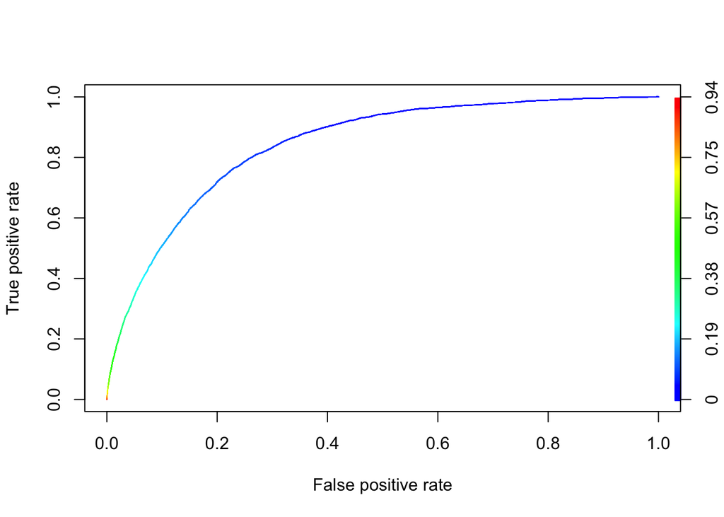

Because the dataset contains significantly more people who have never reported having heart disease ( 292,422) compared to the people who have reported having heart disease (27,373), we must balance the data. Otherwise, it will lower the accuracy of our model and lead to biased conclusions. In order to solve this problem, we use the following method to balance the original dataset. We first select the rows according to “Yes”(1) or “No”(0) in HeartDisease. Then, we randomly select equal amount of data of “No” in `HeartDisease` as the amount of “Yes” in `HeartDisease` and recombine them with the original data that have heart disease, which provides us a new balanced dataset. Then, we try to use it to train the model again.

## New Dataset

#### Data Visualization

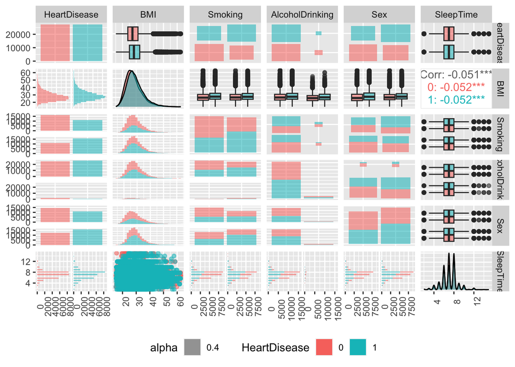

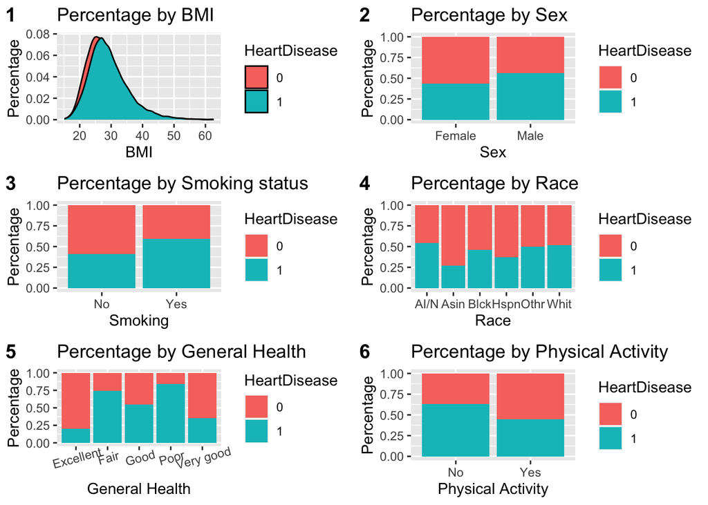

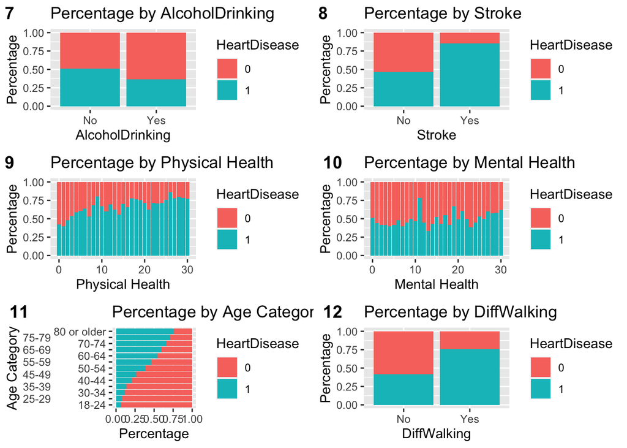

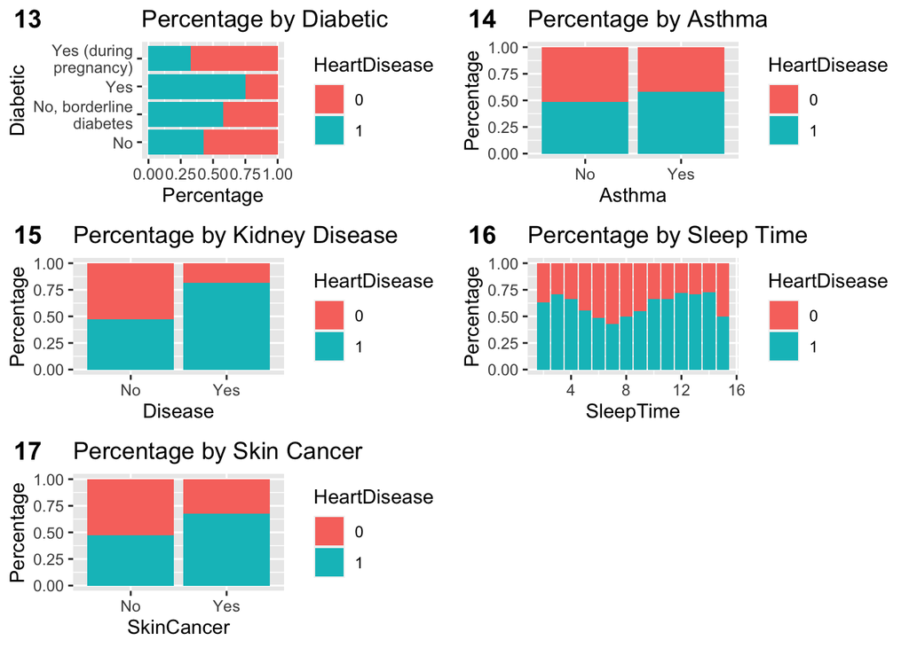

## Training and Testing of Balanced Data

#### GLM Model

```
##
## Call:
## glm(formula = HeartDisease ~ ., family = "binomial", data = train_new)
##
## Deviance Residuals:
##     Min       1Q   Median       3Q      Max
## -3.1146  -0.7837   0.1257   0.8154   2.9070
##
## Coefficients:
##                                  Estimate Std. Error z value Pr(>|z|)
## (Intercept)                     -1.586265   0.174324  -9.100  < 2e-16 ***
## BMI                              0.008858   0.002079   4.260 2.04e-05 ***
## SmokingYes                       0.374273   0.024454  15.305  < 2e-16 ***
## AlcoholDrinkingYes              -0.224357   0.052547  -4.270 1.96e-05 ***
## StrokeYes                        1.149378   0.050858  22.600  < 2e-16 ***
## PhysicalHealth                   0.004988   0.001572   3.174 0.001503 **
## MentalHealth                     0.007374   0.001609   4.583 4.58e-06 ***
## DiffWalkingYes                   0.250717   0.033836   7.410 1.26e-13 ***
## SexMale                          0.715922   0.024833  28.830  < 2e-16 ***
## AgeCategory25-29                 0.231160   0.149116   1.550 0.121093
## AgeCategory30-34                 0.515675   0.137120   3.761 0.000169 ***
## AgeCategory35-39                 0.708676   0.131354   5.395 6.85e-08 ***
## AgeCategory40-44                 1.040473   0.125394   8.298  < 2e-16 ***
## AgeCategory45-49                 1.298693   0.121597  10.680  < 2e-16 ***
## AgeCategory50-54                 1.713607   0.117215  14.619  < 2e-16 ***
## AgeCategory55-59                 2.000883   0.115114  17.382  < 2e-16 ***
## AgeCategory60-64                 2.290993   0.113909  20.112  < 2e-16 ***
## AgeCategory65-69                 2.598987   0.113530  22.892  < 2e-16 ***
## AgeCategory70-74                 2.887615   0.113775  25.380  < 2e-16 ***
## AgeCategory75-79                 3.108909   0.115630  26.887  < 2e-16 ***
## AgeCategory80 or older           3.422842   0.115327  29.679  < 2e-16 ***
## RaceAsian                       -0.410917   0.137455  -2.989 0.002795 **
## RaceBlack                       -0.244620   0.102510  -2.386 0.017019 *
## RaceHispanic                    -0.124420   0.103103  -1.207 0.227527
## RaceOther                        0.028838   0.114067   0.253 0.800408
## RaceWhite                       -0.055861   0.092645  -0.603 0.546532
## DiabeticNo, borderline diabetes  0.126101   0.073058   1.726 0.084339 .
## DiabeticYes                      0.498183   0.031447  15.842  < 2e-16 ***
## DiabeticYes (during pregnancy)   0.123903   0.162222   0.764 0.444995
## PhysicalActivityYes              0.012614   0.028578   0.441 0.658942
## GenHealth                       -0.503296   0.014211 -35.415  < 2e-16 ***
## SleepTime                       -0.028799   0.008377  -3.438 0.000586 ***
## AsthmaYes                        0.290365   0.034557   8.403  < 2e-16 ***
## KidneyDiseaseYes                 0.634617   0.052130  12.174  < 2e-16 ***
## SkinCancerYes                    0.101838   0.035821   2.843 0.004469 **
## ---
## Signif. codes:  0 '***' 0.001 '**' 0.01 '*' 0.05 '.' 0.1 ' ' 1
##
## (Dispersion parameter for binomial family taken to be 1)
##
##     Null deviance: 60247  on 43458  degrees of freedom
## Residual deviance: 42992  on 43424  degrees of freedom
## AIC: 43062
##
## Number of Fisher Scoring iterations: 5
```

#### Confusion Matrix

```
##
##     FALSE TRUE
##   0  4067 1385
##   1  1144 4269
```

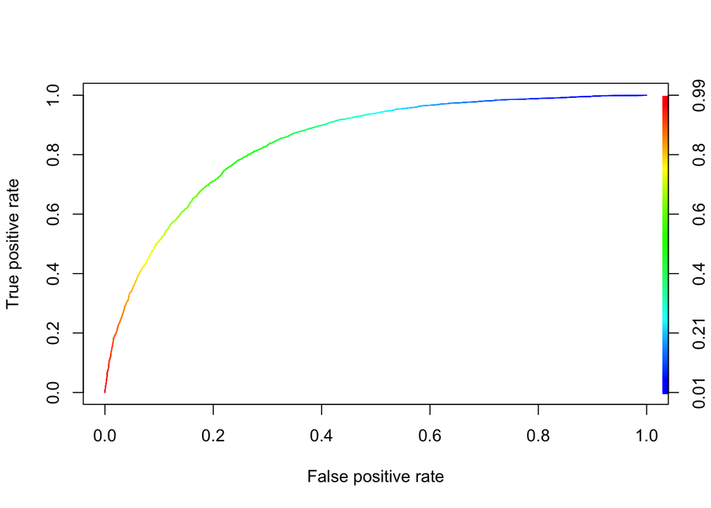

# Conclusion

### Analysis

# References

#### Dataset:

https://www.kaggle.com/datasets/kamilpytlak/personal-key-indicators-of-heart-disease

#### Literature Reivew:

[1] “Cardiovascular Diseases (Cvds).” World Health Organization, World Health Organization, 11 June 2021, www.who.int/news-room/fact-sheets/detail/cardiovascular-diseases- (cvds).

[2] Bansal, Manish. “Cardiovascular Disease and COVID-19.” Diabetes Metabolic Syndrome: Clinical Research Reviews, vol. 14, no. 3, May 2020, pp. 247–250., doi:https://doi.org/10.1016/

[3] Ridker, Paul M. “Clinical Application of C-Reactive Protein for Cardiovascular Disease Detection and Prevention.” Circulation, vol. 107, no. 3, 2003, pp. 363–369., doi:10.1161/01.cir.0000053730.47739.3c.

[4] Celermajer, David S., et al. “Cardiovascular Disease in the Developing World.” Journal of the American College of Cardiology, vol. 60, no. 14, Oct. 2012, pp. 1207–1216., doi:10.1016/j.jacc.2012.03.074.

[5] Getz, Godfrey S., and Catherine A. Reardon. “Nutrition and Cardiovascular Disease.” Arteriosclerosis, Thrombosis, and Vascular Biology, vol. 27, no. 12, 22 Oct. 2007, pp. 2499–2506., doi:10.1161/atvbaha.107.155853.

[6] “Training and Test Sets: Splitting Data; Machine Learning; Google Developers.” Google, 18 July 2022, https://developers.google.com/machine-learning/crash-course/training-and-test-sets/splitting-data?hl=en.

[7]“How to Interpret Glm Output in R (With Example).” Statology, 23 Feb. 2022, www.statology.org/interpret-glm-output-in-r. Accessed 7 Dec. 2022.

[8]“How to Calculate F1 Score in R (Including Example).” Statology, 8 Sept. 2021, www.statology.org/f1-score-in-r. Accessed 6 Dec. 2022.

[9]Chan, Carmen. “What Is a ROC Curve - How to Interpret ROC Curves.” Displayr, 23 Aug. 2022, www.displayr.com/what-is-a-roc-curve-how-to-interpret-it.